# Tratar imagen con R

Daniel Marín

13 de agosto de 2018

Instalamos los paquetes

```r
install.packages(c("OpenImageR","ClusterR"))
```

Ubicamos nuestro directorio de trabajo

```r
getwd() #Obtenemos el directorio de trabajo
setwd("../Desktop/Imagenes en R") #Cambiamos directorio de trabajo
```

Cargamos las librerias

```r
library(OpenImageR)
library(ClusterR)
```

Cargamos la imagen del gato

```r
imagen <- "Gato.jpg"
img <-OpenImageR::readImage(imagen)
```

Redimencionamos la imagen

```r
imagen.rescal <- resizeImage(img, 350, 350, method = "bilinear" )
```

- **nearest =** Simplemente aumenta el tamaño de cada píxel.
- **Bilineal =** Tiene en cuenta los valores en los píxeles conocidos que rodean a uno dado en una vecindad de los 2x2 píxeles más cercanos. y Luego promedio estos valores para obtener el nuevo varlor.

Mostrar imagen

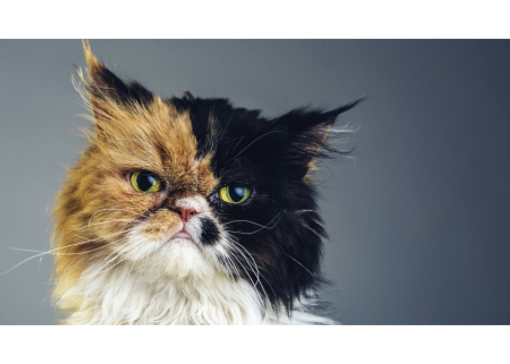

```r
imageShow(img)
```

Vectorizar la imagen

```r
img.vector <- apply(imagen.rescal, 3, as.vector)
dim(img.vector)
```

```
## [1] 122500      3
```

Utilizamos el metodo de minibatch para segmentar la imagen

```r
mbkm <- MiniBatchKmeans(img.vector,clusters =10, batch_size = 20, num_init =5,
                        max_iters = 100, init_fraction = 0.2, early_stop_iter = 10
                        , verbose = F, initializer = "kmeans++")
```

- **Clusters =** Es el número de cluster que queremos
- __ batch_size = __ Es el ta,año del mini batch
- __ num_init = __ Número de veces que el algoritmos debe ser corrido con diferentes centriodes
- __ max_iters = __ Numero maximo de iteraciones
- __ init_fraction = __ Porcentaje de datos para inicializar los centros
- __ initializer = __ Metodo de inicio optimal_init, quantile_init, kmeans++ and random.
- __ early_stop_iter = __ Número de iteraciones despues de calcular los centroids con el mejor error cuadratico medio.
- __ verbose __ = Indica si queremos que el proceso se muestre.

```r
mbkm
```

```
## $centroids
##            [,1]      [,2]      [,3]
##  [1,] 0.2864122 0.1924978 0.1341833
##  [2,] 0.5490196 0.5843137 0.5921569
##  [3,] 0.7569860 0.7443137 0.6882129
##  [4,] 0.1056198 0.1161801 0.1301585
##  [5,] 0.7279792 0.6068027 0.4168948
##  [6,] 0.3620856 0.4013013 0.4326739
##  [7,] 0.2974158 0.3329900 0.3696847
##  [8,] 0.4469916 0.4822857 0.5018936
##  [9,] 0.5021240 0.3707147 0.1694518
## [10,] 0.2399792 0.2751389 0.3136337
##
## $WCSS_per_cluster
##      [,1]        [,2]        [,3]       [,4] [,5]        [,6]        [,7]
## [1,]    0 0.002495842 0.007550814 0.01973268    0 0.000215901 0.003850584
##             [,8]        [,9]       [,10]
## [1,] 0.004196443 0.001926857 0.001402629
##
## $best_initialization
## [1] 3
##
## $iters_per_initialization
##      [,1] [,2] [,3] [,4] [,5]
## [1,]   15   16   20   10   17
##
## attr(,"class")
## [1] "k-means clustering"
```

Predeccimos sobre el modelo construido anteriormente

```r
prmb <- predict_MBatchKMeans(img.vector,mbkm$centroids)
```

Obtenemos los k centroides

```r
getcetro <- mbkm$centroids
```

Construimos la nueva imagen predicha

```r
newimg <- getcetro[prmb,]
```

Redimencionamos la nueva imagen

```r
dim(newimg) <- c(nrow(imagen.rescal),ncol(imagen.rescal),3)
```

Mostramos la nueva imagen

[figure not shown]

```r
imageShow(newimg)
```

## Exportar las imagen

```r
pdf(file="Gato.pre.pdf",width = 3000, height = 3000,)
imageShow(newimg)
dev.off()
```